# Potential conflicts in transatlantic flights

# Wind optimal trajectories

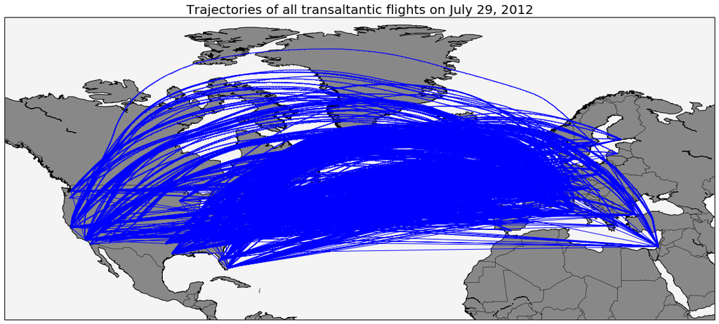

```python
worldmap = analysis.prepareWorldMapPlot(llcrnrlon=-140, llcrnrlat=10, urcrnrlon=50, urcrnrlat=85)
analysis.addTrajectories(worldmap, trajectories)
plt.title('Trajectories of all transaltantic flights on July 29, 2012', fontsize=20);
```

# Pairwise Potential Conflicts

- Spatial Conflict: Trajectory points to close to each other
- Real Conflict: Spatial conflict and arrival at the same time
- *Potential Conflict*: Spatial conflict which can become real

[figure not shown]

# Spatial Conflict Detection

Coarse grid algorithm (Olga Rodionova)

[figure not shown]

# Spatial Conflict Detection

Coarse grid algorithm (Olga Rodionova)

[figure not shown]

# Spatial Conflict Detection

Coarse grid algorithm (Olga Rodionova)

[figure not shown]

# Spatial Conflict Detection

Coarse grid algorithm (Olga Rodionova)

[figure not shown]

# Spatial Conflict Detection

Coarse grid algorithm (Olga Rodionova)

[figure not shown]

# Spatial Conflict Detection

Coarse grid algorithm (Olga Rodionova)

[figure not shown]

# Spatial conflicts in wind optimal trajectories

Huge number of spatial conflicts: $N_\text{spatial} = 33878$

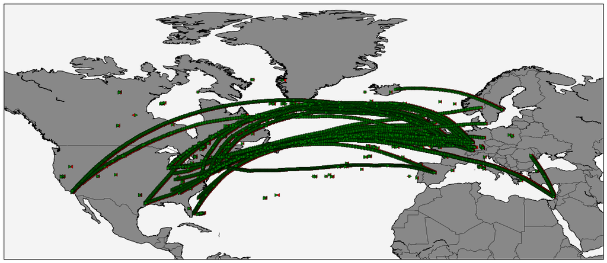

```python
worldmap = analysis.prepareWorldMapPlot(llcrnrlon=-140, llcrnrlat=10, urcrnrlon=50, urcrnrlat=85)
analysis.addPointConflicts(worldmap, rawPointConflicts[60])
```

# Categorize spatial conflicts

Reduce the vast number of spatial conflicts by categorizing:

- Point Conflict: Isolated in time $N_\text{point} = 2519$
- Parallel conflict: Point conflicts consecutive in time $N_\text{parallel} = 1649$
- Reduction of $88 \%$

[figure not shown]

# Potential conflict calculation

Algorithm:

1. For each flight, order conflicts in time
2. For each spatial conflict, calculate the maximal delay of both flights
3. Remove spatial conflicts which can not become real conflicts
4. Repeat the above steps until convergence ($N_\text{spatial}$ invariant)

[figure not shown]

Delays $d_i$ determine the arrival time $t$ at the conflict

# Subsets of the data

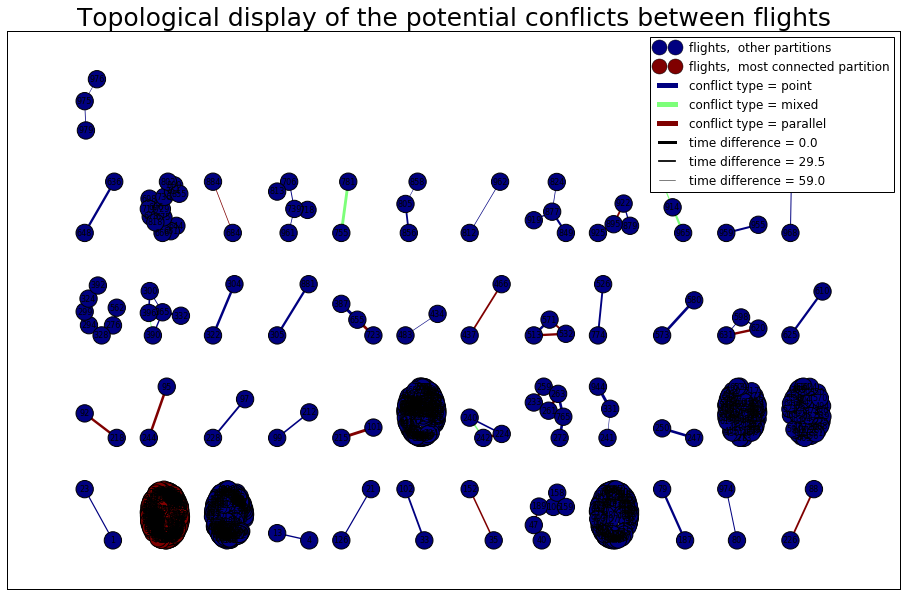

```python
G = analysis.getConflictGraph(pointConflicts[60], parallelConflicts[60])
plt.figure(figsize=(16,10))
plt.xticks([])
plt.yticks([])
plt.title("Topological display of the potential conflicts between flights", fontsize=25)
analysis.plotGraph(G, connectedComponents=True)
```

# Subsets of the data

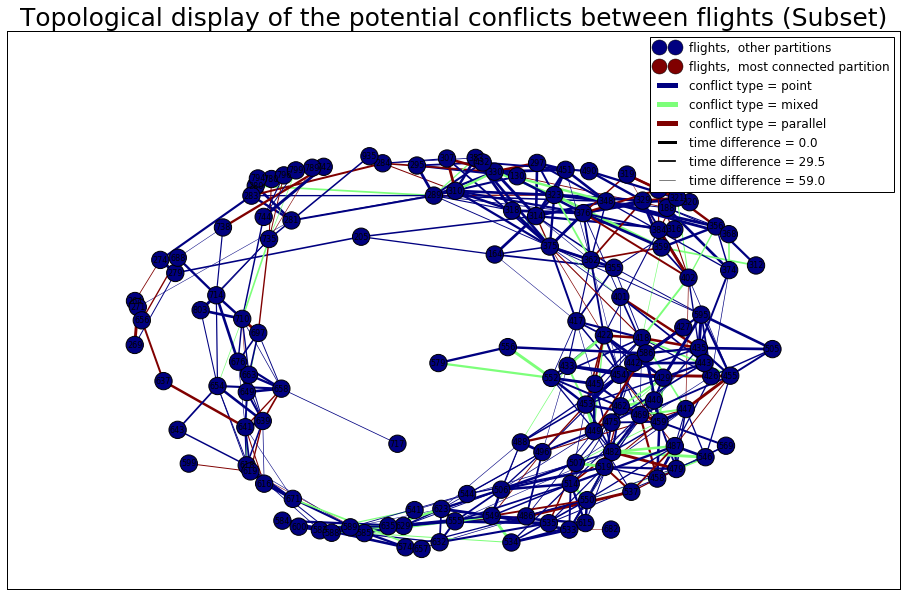

```python
G = analysis.getConflictGraph(pointConflicts[60], parallelConflicts[60])
plt.figure(figsize=(16,10))
plt.xticks([])
plt.yticks([])
plt.ylim(1.4, 2.8)
plt.xlim(9.3, 10.7)
plt.title("Topological display of the potential conflicts between flights (Subset)", fontsize=25)
analysis.plotGraph(G, connectedComponents=True)
```

# Outlook

- Disconnected subgraphs are natural subsets
- Try different subsets for Quantum Annealing
- Use subgraphs in hybrid approach